# Empleando modelo Lotka - Volterra

## ¿Que es el modelo?

### El modelo de lotka volterra es una forma de relacionar el comportamiento de dos especies diferentes en un entorno controlado y la forma en la que el comportamiento de estos los afecta mutuamente

### implementación del modelo en python

```python
import matplotlib.pyplot as plt
from random import *
from numpy import *
import sys
```

### Se cuenta con el siguiente código proporcionado en la clase de graficación computacional. Este codigo fue ligeramente modificado para implementarl el metodo principal en forma de funcion. El objetivo de esta práctica es entender dicho código proporcionado y jugar con las variables después de haber analizado dicho código y entenderlo completamente.

```python
def funcionLotka_Volterra(x,y,a,b,c,e,t,dt,max_time):
    t_list = []; x_list = []; y_list = []

    # initialize lists
    t_list.append(t); x_list.append(x); y_list.append(y)

    while t < max_time:
        # calc new values for t, x, y
        t = t + dt
        x = x + (a*x - b*x*y)*dt
        y = y + (-c*y + e*x*y)*dt

        # store new values in lists
        t_list.append(t)
        x_list.append(x)
        y_list.append(y)

    # Plot the results
    p = plt.plot(t_list, x_list, 'b', t_list, y_list, 'r', linewidth = 2)

    plt.show()
```

### max_time = 100  representa el máximo de tiempo que durara el modelo.

### t = 0  representa un inicio en el tiempo. Empezando desde 0

### x = 1.0  representa el numero inicial de presas (cebras).

### y = 0.5  representa el numero inicial de depredadores(leones).

### Con estos parámetros se puede observar a continuación que la presa cuenta con una alta taza de crecimiento pero a pesar de ello el éxito que tiene el depredador junto con su baja taza de fallecimiento logra reducir drásticamente el numero de presas. Pero conforme mas presas caza este se va quedando cada vez con menos alimento llevando a que el índice de fallecimiento del depredador crezca exponencialmente.

## MODELO CON VARIABLES POR DEFECTO

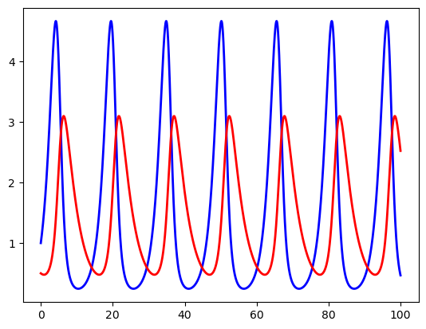

```python
a = 0.7; b = 0.5; c = 0.3;  e = 0.2
dt = 0.0001; max_time = 100

# initial time and populations
t = 0; x = 1.0; y = 0.5
funcionLotka_Volterra(x,y,a,b,c,e,t,dt, max_time)
```

## 1) MODELO CON LA 1A MODIFICACIÓN

### Se va realizar una ligera modificación para que la taza de crecimiento de las presas sea mayor. Para ello voy a modificar la variable a que representa dicha taza de crecimiento. Pasando de un 0.7 a un 0.9.

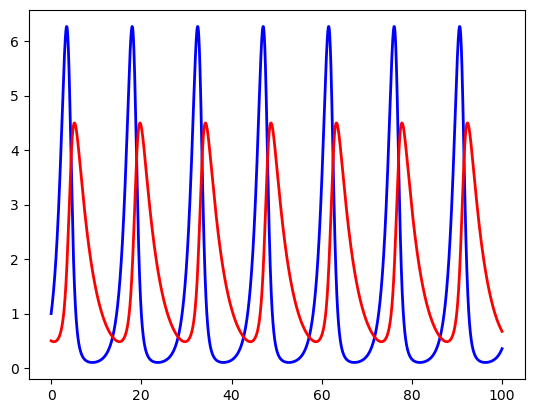

```python
a = 0.9; b = 0.5; c = 0.3;  e = 0.2
dt = 0.0001; max_time = 100

# initial time and populations
t = 0; x = 1.0; y = 0.5
funcionLotka_Volterra(x,y,a,b,c,e,t,dt, max_time)
```

### Tras este cambio se puede observar que la relación entre el número de presas, así como el numero de depredadores se mantiene parecido al caso anterior. Con la diferencia de que ahora hay un mayor número de presas tanto como de depredadores.

## 2) MODELO CON LA 2A MODIFICACIÓN

### Ahora se realizará una modificación en la variable b que representa el efecto de la depredación sobre la presa. Manteniendo los valores por defecto. Se va modificar de un 0.5 a un 0.8.

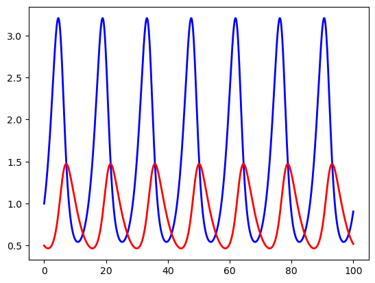

```python
a = 0.7; b = 0.8; c = 0.3;  e = 0.2
dt = 0.0001; max_time = 100

# initial time and populations
t = 0; x = 1.0; y = 0.5
funcionLotka_Volterra(x,y,a,b,c,e,t,dt, max_time)
```

### Tras modificar el efecto de la depredación sobre la presa se puede observar que el efecto al ser mayor se observa que con un menor numero de depredadores se logra cazar un gran numero de presas. Llevándolos rápidamente a una escasez de preas que no les da el tiempo suficiente para propagarse y llevarlos rápidamente a la muerte natural por falta de alimento. Teniendo un efecto más grande en los depredadores debido a su gran número de muertes.

## 3) MODELO CON LA 3A MODIFICACIÓN

### Ahora se va a modificar la tasa natural de muerte del depredador en ausencia de la presa. En la variable c pasamos de tener un valor de 0.3 a un 0.6 conservando los valores por defecto.

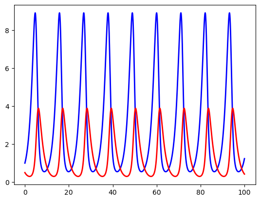

```python
a = 0.7; b = 0.5; c = 0.6;  e = 0.2
dt = 0.0001; max_time = 100

# initial time and populations
t = 0; x = 1.0; y = 0.5
funcionLotka_Volterra(x,y,a,b,c,e,t,dt, max_time)
```

## 4) MODELO CON LA 4A MODIFICACION

### En este punto se va modificar el parámetro de la eficiencia y tasa de propagación del depredador en presencia de la presa. Pasando en el parámetro e de 0.2 a un 0.6

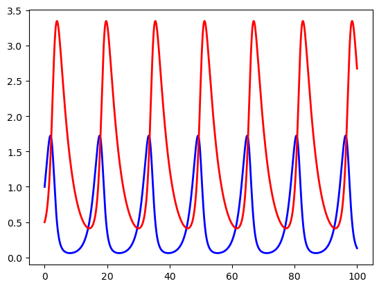

```python
a = 0.7; b = 0.5; c = 0.3;  e = 0.6
dt = 0.0001; max_time = 100

# initial time and populations
t = 0; x = 1.0; y = 0.5
funcionLotka_Volterra(x,y,a,b,c,e,t,dt, max_time)
```

### Después de haber modificado este parámetro se puede observar que los depredadores se reproducen y propagan rápidamente cuando el numero de presas va en aumento. Pero apenas empiezan a cazar en un gran numero estos sufren en su tasa de propagación debido al declive de las presas. Viéndose directamente afectados cuando cazan mas de que crecen las presas.

## 5) MODELO CON LA 5A MODIFICACIÓN

### Tras haber analizado y experimentado con los 4 parámetros principales de este modelo. Se ha obtenido un mejor entendimiento de la forma en la que afecta cada uno de los parámetros al modelo y al equilibrio que existe en el. Ahora se va a intentar obtener un modelo en donde el número de presas y depredadores sea lo más parecido posible. para esto se modificarán todos los parámetros poniéndolos en 0.5Modelo con variables por defecto.

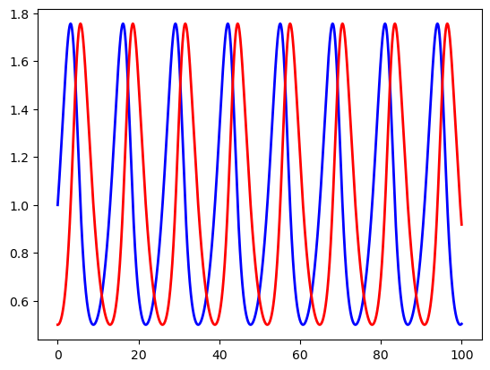

```python
a = 0.5; b = 0.5; c = 0.5;  e = 0.5
dt = 0.0001; max_time = 100

# initial time and populations
t = 0; x = 1.0; y = 0.5
funcionLotka_Volterra(x,y,a,b,c,e,t,dt, max_time)
```

### Se puede observar que tanto el número de presas como el número de depredadores se encuentran en un constante equilibrio muy delicado ya que el número de presas como de depredadores es el mismo pero desfasado ligeramente en el tiempo. así como el número de presas va en aumento el número de depredadores también. apenas el depredador empieza a cazar más presas de lo que crecen el número de presas empieza a disminuir y poco después cuando esto sucede el número de depredadores también ya que empiezan a morir naturalmente por falta de comida.